# MAST30027: Metropolis-Hastings (MH) algorithm and Gibbs Sampler

Week 11

**Objectives of the Tutorial/Lab** By the end of this tutorial, you should be able to:

- Derive conditional distributions for bivariate normal models.
- Implement the Gibbs sampler.
- Assess the effect of the proposal step size on the performance of the MH algorithm.
- Evaluate the performance of MH using Markov chain outputs: checking autocorrelation, effective sample size, convergence, acceptance rates.

## Question 1

Suppose that $\mathbf{X} = \begin{pmatrix} X_1 \\ X_2 \end{pmatrix} \sim N(\boldsymbol\mu, \boldsymbol\Sigma)$, with $\boldsymbol\mu = \begin{pmatrix} \mu_1 \\ \mu_2 \end{pmatrix}$ and $\boldsymbol\Sigma = \begin{pmatrix} \sigma^2_1 & \sigma_{12} \\ \sigma_{12} & \sigma^2_2 \end{pmatrix}$.

Show that the conditional distribution of $X_1|X_2=x_2$ is normal with mean $\mu_1 + (x_2-\mu_2)\sigma_{12}/\sigma^2_2$ and variance $\sigma^2_1 - \sigma_{12}^2/\sigma^2_2$.

Write an R function that uses the Gibbs sampler to generate a sample of size $n = 1000$ from the $N\left( \begin{pmatrix} 0 \\ 0 \end{pmatrix}, \begin{pmatrix} 4 & 1 \\ 1 & 4 \end{pmatrix} \right)$ distribution. Run at least two Gibbs sampling chains with different initial values. Make trace plots for $X_1$ and $X_2$ and see if samples from different chains are mixed well and behave similarly.

**🔎 Hint**

> Use the conditional distributions derived in part (a). Starting from the initial values, in each iteration, sample $X_1$ conditional on $X_2$, then sample $X_2$ conditional on the updated $X_1$. Record the X values in all iterations. Repeat the process using a different set of initial values and do trace plots to see if these chains converge to the same distribution.

**💡 Incomplete solution for R code**

```r
set.seed(200)

# params
mu1 <-
mu2 <-
s1  <-
s1  <-
s2  <-

# sample size
nreps <-

# 1st initial values
x1 <-
x2 <-

Gsamples <- matrix(nrow=nreps, ncol= 2)
Gsamples[1,] <- c(x1, x2)

# main loop
for (i in 2:nreps) {
  x1 <- rnorm(1,     ,     )
  x2 <- rnorm(1,     ,     )
  Gsamples[i,] <- c(x1, x2)
}
Gsamples1 = Gsamples

# 2nd initial values
x1 <-
x2 <-

Gsamples <- matrix(nrow=nreps, ncol= 2)
Gsamples[1,] <- c(x1, x2)

# main loop
for (i in 2:nreps) {
  x1 <- rnorm(1,     ,     )
  x2 <- rnorm(1,     ,     )
  Gsamples[i,] <- c(x1, x2)
}
Gsamples2 = Gsamples

# do trace plots for both chains for x1

# do trace plots for both chains for x2

# check if they are mixed well
```

Use your simulator to estimate $\Pr(X_1 \geq 0, X_2 \geq 0)$. To get a feel for the convergence rate, calculate the estimate using samples $\{1, \ldots, k\}$, for $k = 1, \ldots, n$, and then plot the estimates against $k$.

**🔎 Hint**

> Check whether each pair of sample satisfies the condition (i.e., $X_1 \geq 0, X_2 \geq 0$). You can use `cumsum` to estimate the probability based on the first $k$ samples, for $k=1,\ldots, n$.

**💡 Incomplete solution for R code**

```r
success <-       # a vector of TRUE/FALSE statement about whether X1>=0 and X2>=0
mean(success)

# plot the estimates for the probability using samples 1,...,k, using function cumsum(success)
plot(1:nreps,     , type="l", xlab="k", ylab="prob", ylim=c(0,1))
```

Now change $\boldsymbol\Sigma$ to $\begin{pmatrix} 4 & 2.8 \\ 2.8 & 4 \end{pmatrix}$ and generate another sample of size 1000. What do the traces/estimates look like now?

**🔎 Hint**

> Implement the Gibbs sampler with the updated covariance. Procedures are the same as part (b) and (c).

> Compare the new trace plot with the previous one. You can label the lines using `legend`.

## Question 2

**Metropolis-Hastings** [**We already solved problems (a), (b), and (c) in the week 10. This week, solve the problem (d), (e), and (f).**]

Recall that $\mathbf{X} = \begin{pmatrix} X_1 \\ X_2 \end{pmatrix} \sim N(\boldsymbol\mu, \boldsymbol\Sigma)$, with $\boldsymbol\mu = \begin{pmatrix} \mu_1 \\ \mu_2 \end{pmatrix}$ and $\boldsymbol\Sigma = \begin{pmatrix} \sigma^2_1 & \sigma_{12} \\ \sigma_{12} & \sigma^2_2 \end{pmatrix}$, if and only if $\mathbf{X}$ has joint density
$$f_{\boldsymbol\mu, \boldsymbol\Sigma}(\mathbf{x}) = \frac 1{2\pi|\boldsymbol\Sigma|^{1/2}} \exp\left( -\frac{1}{2} (\mathbf{x} - \boldsymbol\mu)^T \boldsymbol\Sigma^{-1} (\mathbf{x} - \boldsymbol\mu) \right),$$
where $\mathbf{x} = \begin{pmatrix} x_1 \\ x_2 \end{pmatrix}$.

Write an R function that evaluates the density of a bivariate normal distribution. The function should take as input the point $\mathbf{x}$, the mean $\boldsymbol\mu$ and the covariance matrix $\boldsymbol\Sigma$.

You will find the functions `solve` and `det` useful.

**💡 Solution**

```r
dbinorm <- function(x, mu, Si) {
  # x and mu are vectors length 2 and Si a 2x2 matric
  # returns the density at x of a bivariate normal mean mu var Si
  exp(-t(x - mu)%*%solve(Si, x - mu)/2)/2/pi/sqrt(det(Si))
}
```

You can check that it is working by noting that `dbinorm(c(1,1), c(0,0), matrix(c(1,0,0,1),2,2))` gives the same answer as `dnorm(1)^2`.

Write a program in R that uses the Metropolis-Hastings algorithm to generate a sample of size $n = 1000$ from the $N\left( \begin{pmatrix} 0 \\ 0 \end{pmatrix}, \begin{pmatrix} 4 & 1 \\ 1 & 4 \end{pmatrix} \right)$ distribution. Use the symmetric random walk proposal distribution $N\left( \mathbf{x}, \sigma^2 I \right)$ with $\sigma = 2.5$.

Use $\mathbf{X}(0) = \begin{pmatrix} 6 \\ -6 \end{pmatrix}$ as your initial state. Report the proportion of accepted values.

**🔎 Hint**

> Recall the steps of the MH algorithm. Starting from an initial value, propose a new sample value according to the proposal distirbution. Then decide whether to accept the proposed value based on the acceptance probability. Repeat this process for the required number of iterations, while recording the value of x at each iteration.

**💡 Incomplete solution for R code**

```r
set.seed(100)
mu <- c(  ,  )                     # mean
Si <- matrix(c( ,  ,  ,  ),  ,  ) # variance
iterations <-        # sample size
startvalue <- c(  ,  )  # initial value for x
sd <-                 # std-dev for proposal chain

chain <- matrix(nrow = iterations + 1, ncol =  2)
chain[1,] <- startvalue
accepted <- 0  # counts num accepted proposals

for (i in  1:iterations){
  proposal <-       # propose x values using proposal distribution and the previous sample values, chain[i,]
  prob <- # compute probability using dbinorm, proposal, chain[i,], mu, Si
  if (is.nan(prob)) prob <- 0 # avoid undefined probability values
  if (runif(1) < prob) {
    # accepted


    } else {
    # if not

  }
}

# acceptance rate
accepted/iterations
```

**💡 Solution**

```r
set.seed(100)
# Metropolis-Hastings simulation of a bivariate normal
# inputs
mu <- c(0, 0)                     # mean
Si <- matrix(c(4, 1, 1, 4), 2, 2) # variance
iterations <- 1000      # sample size
startvalue <- c(6, -6)  # initial value
sd <- 2.5               # std-dev for proposal chain
# main loop
chain <- matrix(nrow = iterations+1, ncol = 2)
chain[1,] <- startvalue
accepted <- 0 # counts num accepted proposals
for (i in 1:iterations){
  proposal <- rnorm(2, chain[i,], sd)
  prob <- dbinorm(proposal, mu, Si)/dbinorm(chain[i,], mu, Si)
  if (is.nan(prob)) prob <- 0
  if (runif(1) < prob) {
    chain[i+1,] <- proposal
    accepted <- accepted + 1
    } else {
      chain[i+1,] <- chain[i,]
    }
}

# acceptance rate
accepted/iterations
```

```
[1] 0.457
```

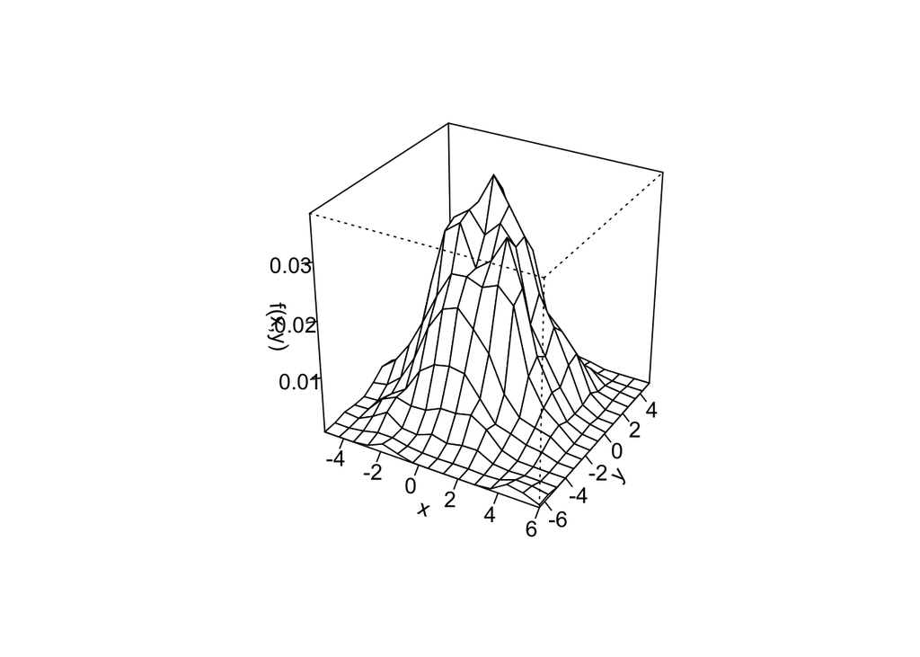

```r
# 2D density plot
library(MASS)
chain_density <- kde2d(chain[,1], chain[,2], n = 15)
persp(chain_density, phi = 30, theta = 30, d = 5, xlab = "x", ylab = "y", zlab = "f(x,y)", ticktype = "detailed")
```

The acceptance rate was 46% (this will vary a little every time you run the program).

To check that the output looks ok, I have plotted (a kernel density estimate of) the joint density. Easier than plotting a joint density would be to plot histograms/densities of the marginal samples, using `hist` or `density`.

Let $\mathbf{X}(n)$ be the $n$-th sample point. Plot $X_i(n)$ and the cumulative averages $\bar{X}_i(n) = n^{-1} \sum_{j=1}^n X_i(j)$, for $i = 1, 2$ (over iteration numbers). The cumulative averages should give a rough idea of how quickly the $\mathbf{X}(n)$ converge in distribution.

**🔎 Hint**

> Plot the sample values across iterations and overlay the cumulative average on the same plot (we can do so using `lines`). The function `cumsum` can be helpful for computing the cumulative averages.

**💡 Incomplete solution for R code**

```r
# cumulative averages
par(mfrow=c(2,1), mar=c(4,4,1,1)) # subfigure configurations

# plot for x1
plot(     , xlab = "iteration", ylab = "x1")
cumavg1 <-          # compute the cumulative average using function cumsum
lines(     , cumavg1, col = "red", lwd=2)

# do the same for x2
```

**💡 Solution**

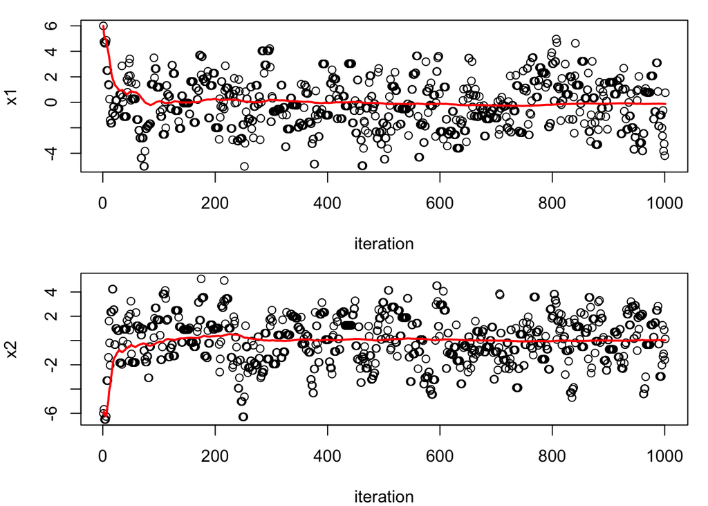

```r
# cumulative averages
par(mfrow=c(2,1), mar=c(4,4,1,1))
plot(chain[,1], xlab = "iteration", ylab = "x1")
cumavg1 <- cumsum(chain[,1])/1:(iterations + 1)
lines(1:(iterations + 1), cumavg1, col = "red", lwd=2)
plot(chain[,2], xlab = "iteration", ylab = "x2")
cumavg2 <- cumsum(chain[,2])/1:(iterations + 1)
lines(1:(iterations + 1), cumavg2, col = "red", lwd=2)
```

**📈 Plotting it using ggplot2**

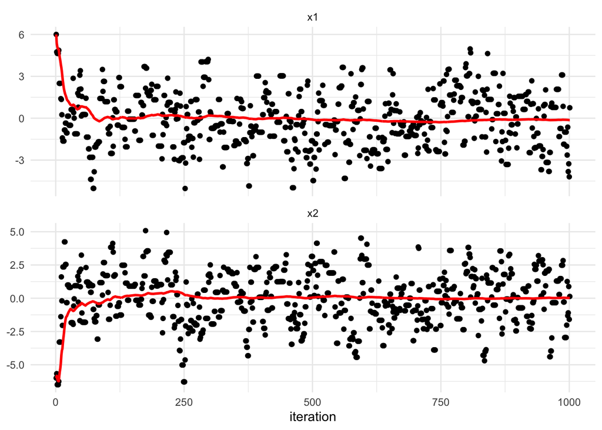

```r
library(ggplot2)
trace_df <- data.frame(
  iteration=rep(seq_len(iterations+1), 2),
  value=c(chain[,1], chain[,2]),
  cumulative_average=c(cumavg1, cumavg2),
  variable=rep(c("x1", "x2"), each=iterations+1))
ggplot(trace_df, aes(iteration)) +
  geom_point(aes(y=value)) +
  geom_line(aes(y=cumulative_average), colour="red", linewidth = 1) +
  facet_wrap(~variable, ncol=1, scales="free_y") +
  labs(y=NULL) +
  theme_minimal()
```

You can use the R functions `cor` or `acf` to estimate the lag 1 autocorrelation $\rho$. Calculate the so called *effective sample size*: $n(1-\rho)/(1+\rho)$ for each variable.

**🔎 Hint**

> We can estimate the lag 1 autocorrelation by computing the correlation between the chain and the same chain shifted by one sample.

Change the standard deviation of the proposal chain to $\sigma = 0.1$ and then $\sigma = 10$. How do the proportion of accepted values, the cumulative averages, and the effective sample size change?

**🔎 Hint**

> We can write a general function for the MH algorithm which allows for adjusting the parameter values in the target distribution as well as the proposal distribution. Run the algorithm using different standard deviation of the proposal and compare their trace plots, acceptance rates, and autocorrelations.

**💡 Incomplete solution for R code**

```r
# reuse the density function we defined in previous session
dbinorm <- function(x, mu, Si) {
  # x and mu are vectors length 2 and Si a 2x2 matric
  # returns the density at x of a bivariate normal mean mu var Si
  exp(-t(x - mu)%*%solve(Si, x - mu)/2)/2/pi/sqrt(det(Si))
}

# we can define a function for the MH algorithm which allows us to adjust the proposal sd
rbinormMH <- function(mu, Si, iterations = 1000, startvalue = c(6, -6), sd = 2.5) {
  # mu = mean, Si = variance, startvalue = initial value, sd = std-dev
  # for proposal chain
  chain <- matrix(nrow = iterations+1, ncol = 2)
  chain[1,] <- startvalue
  accepted <- 0
  for (i in 1:iterations){
    # write the steps we need within the chain, need to update `chain` and `accepted`





  }
  attributes(chain) <- list(dim = c(iterations+1,2),
                            p_accept = accepted/iterations,
                            rho1 = cor(chain[-(iterations+1),1], chain[-1,1]),
                            rho2 = cor(chain[-(iterations+1),2], chain[-1,2]))
  return(chain)
}

par(mfrow=c(3,1), mar=c(4,4,3,1))
X1 <- rbinormMH(mu=    , Si=    , sd = 0.1)
X2 <- rbinormMH(mu=    , Si=    , sd = 2.5)
X3 <- rbinormMH(mu=    , Si=    , sd = 10)


# x1 values in chain 1
plot(X1[,1], xlab = "iteration", ylab = "x1, sd = 0.1",
     main = paste("accepted =", attr(X1, "p_accept"), "rho =", round(attr(X1, "rho1"),4)))
cumavg1 <-
lines(1:(iterations + 1), cumavg1, col = "red")
# repeat it for chain 2 and chain3

# compare and discuss how the proportion of accepted values, the cumulative averages, and the effective sample size change
```

Now change $\boldsymbol\Sigma$ to $\begin{pmatrix} 4 & 2.8 \\ 2.8 & 4 \end{pmatrix}$ and repeat the above analysis. How do things change?

**🔎 Hint**

> Reuse the function for the MH algorithm with the updated covariance matrix. Then draw the diagnostic plots and do comparisons, similar to what we did in the previous section.